# Regional Sales Tracking in Video Games

Abhiraam T.

2023-11-28

## **Analysis/R**

```
## # A tibble: 10 × 2
##    Publisher                    totalglobal
##    <chr>                              <dbl>
##  1 Nintendo                           1789.
##  2 Electronic Arts                    1117.
##  3 Activision                          731.
##  4 Sony Computer Entertainment         606.
##  5 Ubisoft                             472.
##  6 Take-Two Interactive                404.
##  7 THQ                                 338.
##  8 Konami Digital Entertainment        282.
##  9 Sega                                270.
## 10 Namco Bandai Games                  255.
```

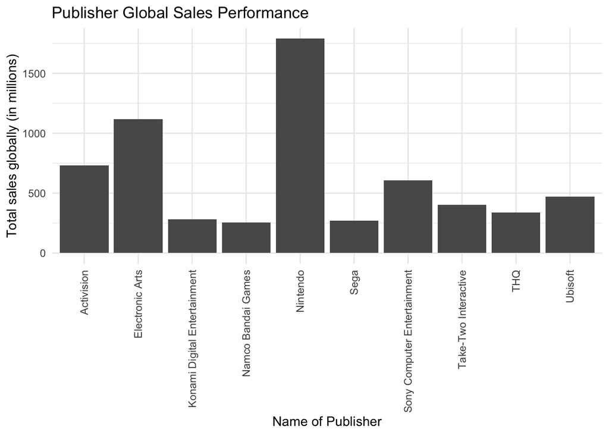

```
## # A tibble: 10 × 2
##    Publisher                   totalna
##    <chr>                         <dbl>
##  1 Nintendo                       817.
##  2 Electronic Arts                599.
##  3 Activision                     433.
##  4 Sony Computer Entertainment    266.
##  5 Ubisoft                        253.
##  6 Take-Two Interactive           223.
##  7 THQ                            208.
##  8 Microsoft Game Studios         157.
##  9 Atari                          110.
## 10 Sega                           109.
```

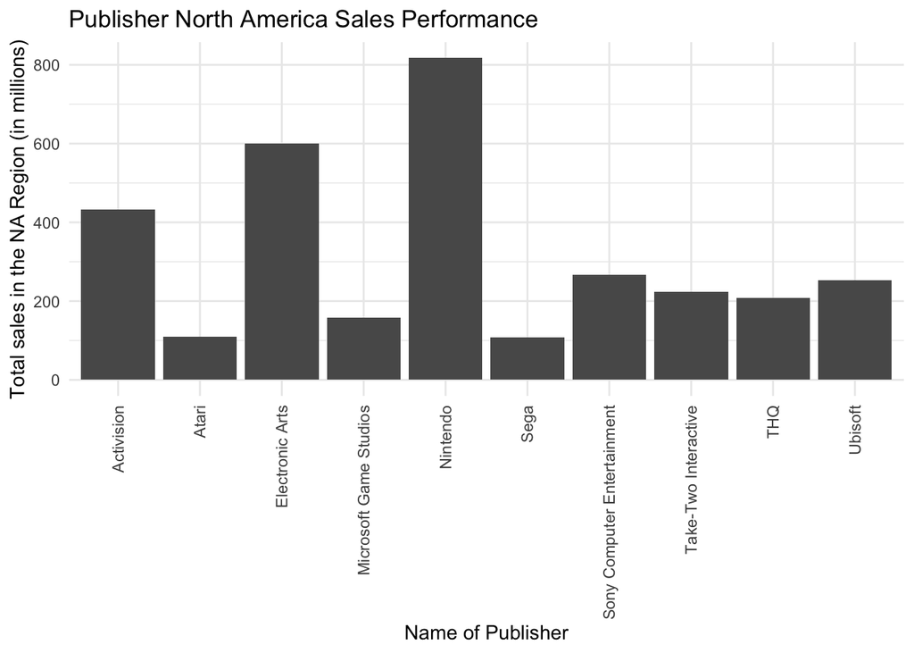

```
## # A tibble: 10 × 2
##    Publisher                    totaleu
##    <chr>                          <dbl>
##  1 Nintendo                       419.
##  2 Electronic Arts                374.
##  3 Activision                     216.
##  4 Sony Computer Entertainment    187.
##  5 Ubisoft                        162.
##  6 Take-Two Interactive           119.
##  7 THQ                             93.8
##  8 Sega                            80.7
##  9 Konami Digital Entertainment    69.0
## 10 Microsoft Game Studios          68.6
```

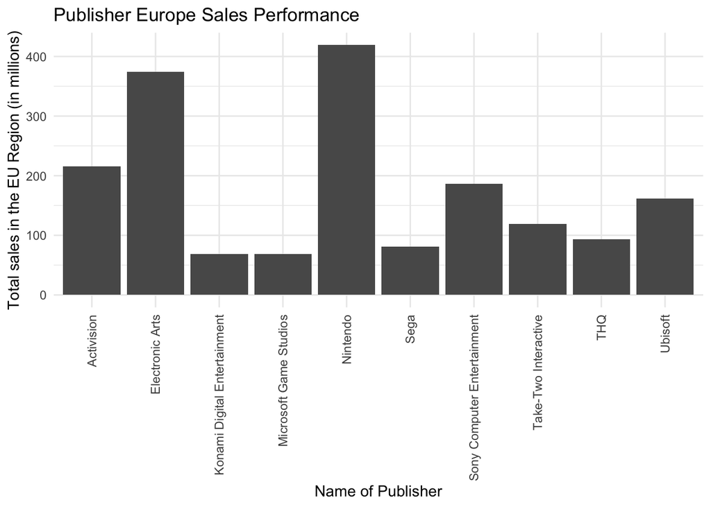

```
## # A tibble: 10 × 2
##    Publisher                    totaljp
##    <chr>                          <dbl>
##  1 Nintendo                       458.
##  2 Namco Bandai Games             128.
##  3 Konami Digital Entertainment    91.4
##  4 Sony Computer Entertainment     74.2
##  5 Capcom                          68.4
##  6 Sega                            57.1
##  7 Square Enix                     50.1
##  8 SquareSoft                      40.1
##  9 Enix Corporation                32.4
## 10 Tecmo Koei                      29.5
```

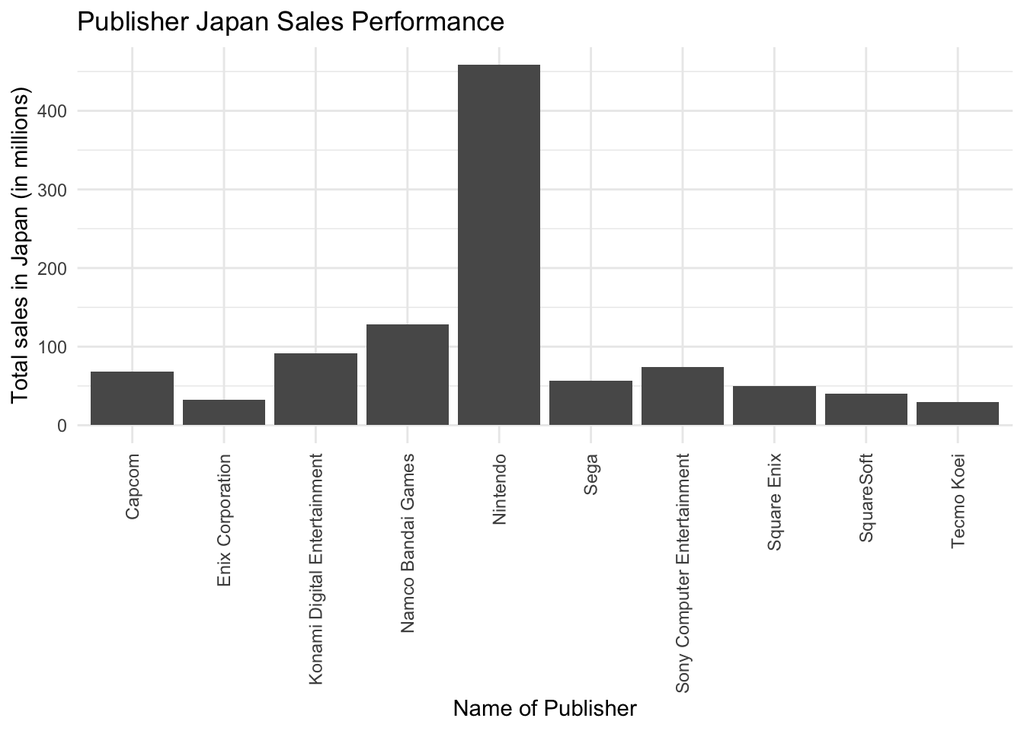

> Publisher Strategies: -Successful publishers exhibit distinct strategies tailored to their target regions. Western publishers tend to fare well in their home regions, while Japanese publishers dominate in Japan. -Inference: Publishers should adopt region-specific strategies, including effective marketing campaigns, partnerships with local entities, and adapting game content to align with cultural preferences.

```
## # A tibble: 10 × 2
##    Platform totalglobal
##    <chr>          <dbl>
##  1 PS2            1256.
##  2 X360            972.
##  3 PS3             939.
##  4 Wii             908.
##  5 DS              807.
##  6 PS              731.
##  7 GBA             318.
##  8 PS4             314.
##  9 PSP             294.
## 10 PC              260.
```

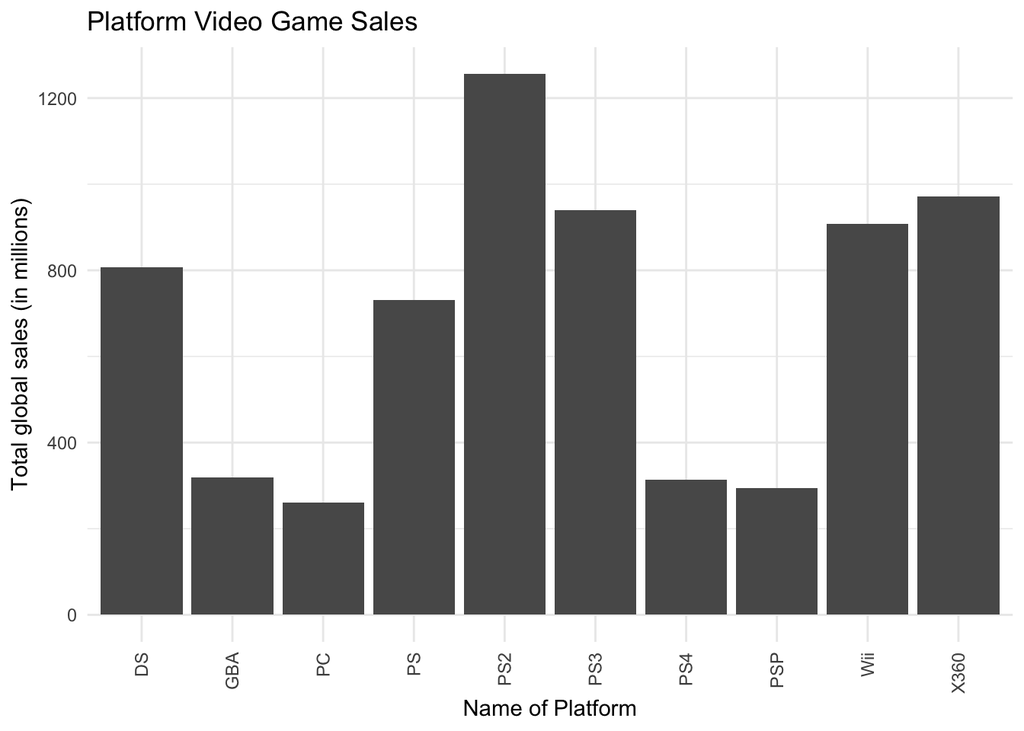

> Platform Preference: -The analysis highlights the significant success of Sony’s platforms, particularly the PlayStation series. This success is consistent across multiple generations, indicating a strong preference for Sony’s gaming consoles. -Inference: Launching a game on Sony platforms increases the likelihood of high sales, potentially due to a loyal user base, exclusive titles, and effective marketing.

```
## # A tibble: 16,719 × 7
##    Platform Name                    pct_na pct_eu  pct_jp pct_other Global_Sales
##    <chr>    <chr>                    <dbl>  <dbl>   <dbl>     <dbl>        <dbl>
##  1 Wii      Wii Sports               0.501 0.351  0.0457     0.102          82.5
##  2 NES      Super Mario Bros.        0.723 0.0890 0.169      0.0191         40.2
##  3 Wii      Mario Kart Wii           0.441 0.359  0.107      0.0926         35.5
##  4 Wii      Wii Sports Resort        0.476 0.334  0.100      0.0900         32.8
##  5 GB       Pokemon Red/Pokemon Bl…  0.359 0.283  0.326      0.0319         31.4
##  6 GB       Tetris                   0.767 0.0747 0.139      0.0192         30.3
##  7 DS       New Super Mario Bros.    0.379 0.307  0.218      0.0966         29.8
##  8 Wii      Wii Play                 0.483 0.317  0.101      0.0982         28.9
##  9 Wii      New Super Mario Bros. …  0.510 0.245  0.166      0.0791         28.3
## 10 NES      Duck Hunt                0.951 0.0223 0.00989    0.0166         28.3
## # ℹ 16,709 more rows
```

```
## # A tibble: 1 × 5
##       n meanna meaneu meanjp meanother
##   <int>  <dbl>  <dbl>  <dbl>     <dbl>
## 1 16719  0.458  0.228  0.243    0.0630
```

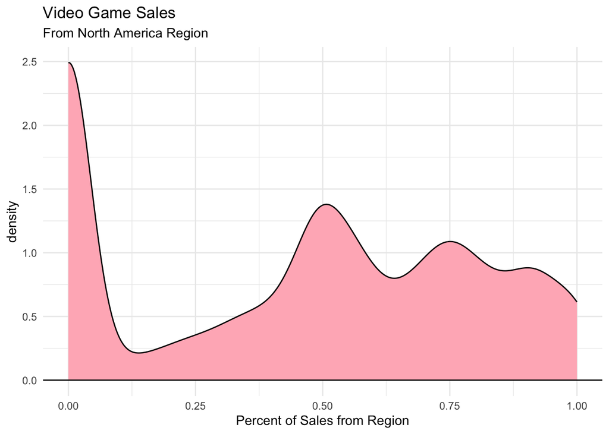

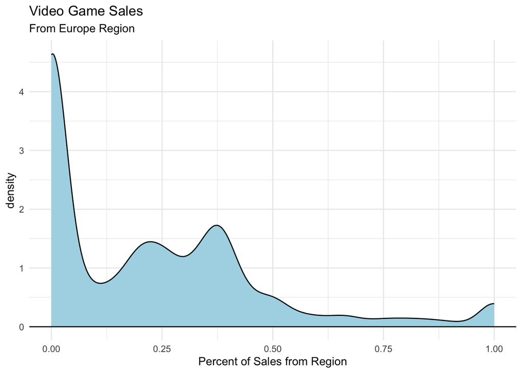